# Introduction

This is an R Markdown template for thesis’ at the Department of Statistics, LMU.

You are not obligated to work with this template (despite we highly recommend it), but for the final submission you need to provide a repository with a similar structure and running code.

To create html output of this intro chapter click the **Knit** button. To create html or pdf (see drop down menu) output of the complete thesis template click the **Knit** button in `00_thesis.Rmd`.

## R Markdown and Bookdown

The template builds on R Markdown and its extension Bookdown.

For a quick overview see the [R Markdown cheat sheet](https://raw.githubusercontent.com/rstudio/cheatsheets/main/rmarkdown.pdf) and for the details the [R Markdown](https://bookdown.org/yihui/rmarkdown) and [Bookdown](https://bookdown.org/yihui/bookdown/) (esp. [Ch. 2.2](https://bookdown.org/yihui/bookdown/markdown-extensions-by-bookdown.html) and [Ch. 3.4](https://bookdown.org/yihui/bookdown/a-single-document.html)) books.

## Including R (or other) Code

You can embed R code as follows:

- directly in a Rmd file, e.g.

A simple table.

|  | speed | dist |
| --- | --- | --- |
|  | Min. : 4.0 | Min. : 2.00 |
|  | 1st Qu.:12.0 | 1st Qu.: 26.00 |
|  | Median :15.0 | Median : 36.00 |
|  | Mean :15.4 | Mean : 42.98 |
|  | 3rd Qu.:19.0 | 3rd Qu.: 56.00 |
|  | Max. :25.0 | Max. :120.00 |

- by sourcing R scripts, e.g.

```r
# you need to use package `here`
source(here::here("code/example-code.R"))
```

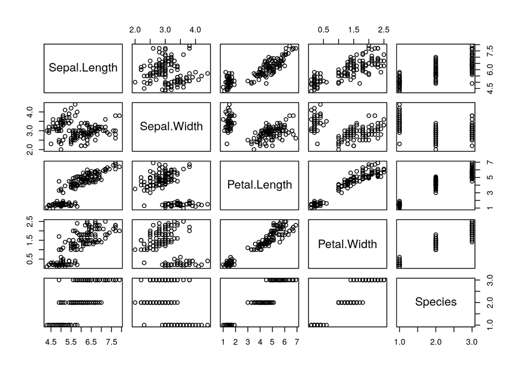

Example plot created in a scoured R script.

## Citation and References

We strongly recommend to use [Zotero](https://www.zotero.org/) as Reference management software (with [Better Bibtex](https://retorque.re/zotero-better-bibtex/) extension). It is free and open source and has a nice [R Studio integration](https://rstudio.github.io/visual-markdown-editing/citations.html) (see also https://github.com/crsh/citr and https://github.com/paleolimbot/rbbt).

See [Bookdown Ch. 2.8](https://bookdown.org/yihui/bookdown/citations.html) on how to cite references in R Markdown and some general background.